# Análisis series temporales con Machine Learning

## 4. Resultados

En este apartado analizaremos conjuntamente las métricas de los modelos aplicados.

```r
results <- predict(model_results_final_ENET,
                   model_results_final_XGB,
                   model_results_final_SVR,
                   prediction_function = list(prediction_function,
                                              prediction_function,
                                              prediction_function),
                   data = data_forecast)
```

Graficamos todos los forecasts en un solo gráfico para poder visualizar más claramente los resultados. Según horizonte temporal

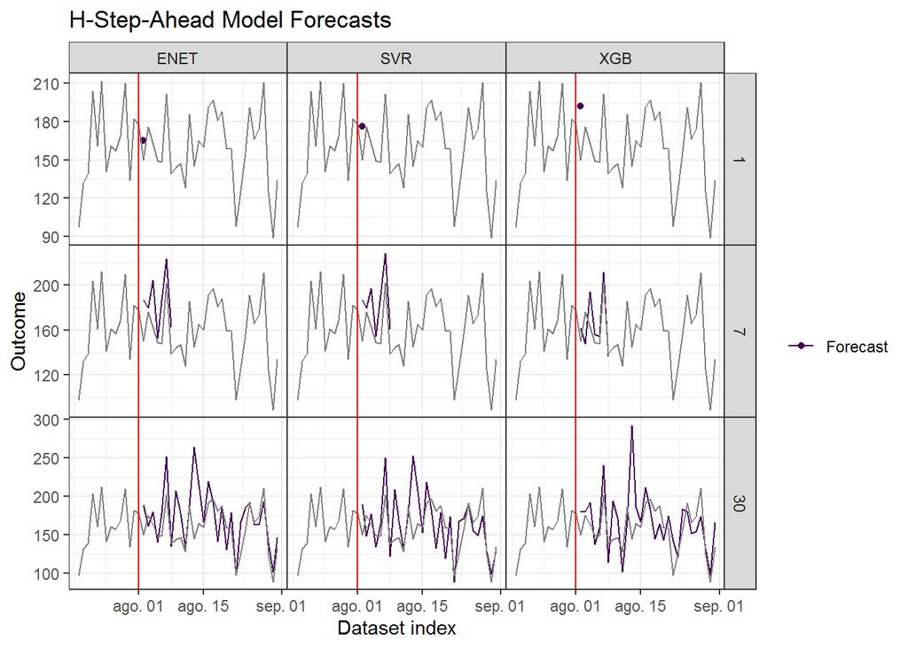

```r
plot(results, data_actual = df_ts[750:793,], actual_indices = dates[750:793])
```

Viendo la comparación de todos los forecasts se podría decir que para el horizonte ‘1’ el mejor modelo sería ENET, para el horizonte ‘7’ sería XGB y finalmente para el horizonte ‘30’ ENET volvería ser el mejor.

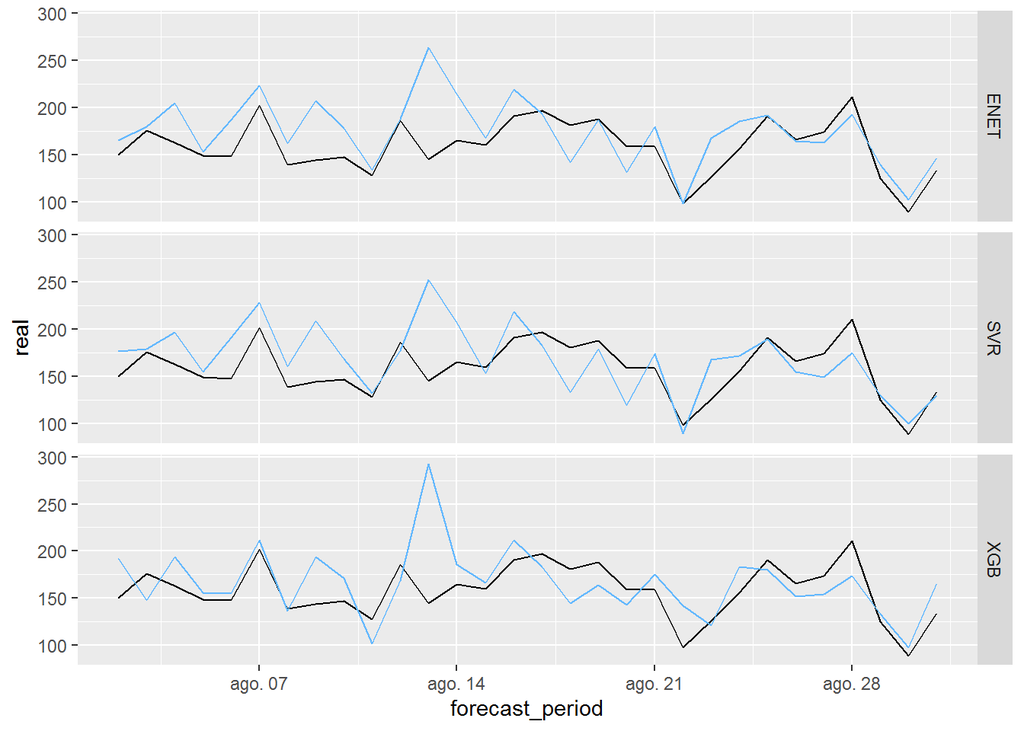

```r
rbind(SVR_combined, ENET_combined, XGB_combined) %>%
  cbind(real = df_ts_test$reservas) %>%
  ggplot()+
    geom_line(aes(x = forecast_period, y = real), colour = "black")+
    geom_line(aes(x = forecast_period, y = reservas_pred), colour = "steelblue1")+
    facet_grid(vars(model))
```

```r
results_error <- return_error(results,df_ts, dates)$error_global %>%
  select(model, mae, rmse) %>%
  rbind(list("NAIVE", naive_mae, naive_rmse)) %>%
  rbind(list("SMA_30", SMA_30_error_forecast[2,3], SMA_30_error_forecast[2,2]))

results_error[,-1] <- lapply(results_error[,-1], round,1)

results_error
```

```
##    model  mae rmse
## 1   ENET 23.5 28.3
## 2    SVR 24.8 28.4
## 3    XGB 25.8 36.2
## 4  NAIVE 32.3 38.8
## 5 SMA_30 24.8 30.5
```

Estos resultados son muy mejorables con los siguientes puntos:

- Haciendo mayor hincapié en la búsqueda de hyperparámetros.
- Añadiendo un modelo para cada periodo adicional de forecast. (Aquí solo hemos aplicado 3 horizontes diferentes para un forecast de 30 periodos).
- Investigando en mayor amplitud la optimización de los retardos de las diferentes variables ya que aquí simplemente hemos cogido retardos a año vista y a un mes vista.